# 1. Numpy

# Datetime

Este es un modulo básico de **python** usado para el manejo de fechas y de horas. Puede ser utilizado en conjunto con las **Listas** y con **numpy**. Los que han trabajado con series de tiempo saben que estas presentan algunos problemas:

- Identificar bisiestos.
- Saberse de memoría que meses son de 30 y cuales de 31 (esto no es tan importante).
- Agregar una variable temporalmente.
- Hacer preguntas temporales.

**datetime** es de utilidad cuando se tratan de resolver este tipo de problemas, sin embargo, es un paso más para llegar a **Pandas**.

```python
import datetime as dt
```

```python
# Fecha actual
dt.datetime.now()
```

```
datetime.datetime(2018, 3, 12, 11, 57, 3, 918356)
```

```python
#Definir una fecha cualquiera:
#Orden: ano, mes, dia, hora, min
Fecha = dt.datetime(2014, 5, 3, 0, 30)
```

```python
#Delta de fecha
DeltaFecha = dt.datetime.now() - Fecha
print DeltaFecha
#Imprimir solo los dias
print DeltaFecha.days
```

```
1409 days, 11:30:17.773833
1409
```

### Ejercicio 1:

Escriba una función que reciba los siguientes parametros de entrada:

- Año de inicio.
- Cantidad de dias.

Y que como resultado entregue una **Lista** que contenga todas las fechas diarias desde el año inicio hasta la fecha final dada la cantidad de días ingresada.

```python
date = dt.datetime(2000,1,1)
```

```python
date + dt.timedelta(days = 24)
```

```
datetime.datetime(2000, 1, 25, 0, 0)
```

```python
def CreaFechas(date, N):
    return [date+dt.timedelta(days = i) for i in range(N)]
```

```python
def CreaFechas(ano, mes, dia, N):
    date = dt.datetime(ano, mes, dia)
    Dates = [date]
    for i in range(N):
        Dates.append(Dates[i]+dt.timedelta(days = 1))
    return Dates
```

Como pueden ver las fechas de **datetime** no son un caracter, pero pueden serlo, y también los caracteres se pueden convertir en **datetime**, para eso usamos dos funciones:

```python
dt.datetime.strptime('2000-05-25 10:25','%Y-%m-%d %H:%M')
```

```
datetime.datetime(2000, 5, 25, 10, 25)
```

```python
dt.datetime.strftime(dt.datetime.now(), u'Es el ano %Y en el mes de %B')
```

```
'Es el ano 2018 en el mes de March'
```

### Lectura de un archivo

Al igual que en todos los lenguajes se puede hacer lectura tanto de **binarios** como de texto **plano**. El primero sólo es legible por la máquina, pero tiende a costar menos tiempo y espacio. El segundo es legible por el ser humano a cambio de más espacio y tiempo de lectura. Algunos formatos **planos comunes** son:

- **txt**: archivos planos de texto codificados normalmente en UTF-8.
- **json**: archivos planos usados para la web.
- **xml**: similares a los json.
- **csv**: Archivo separado por comas, usualmente se emplea en tablas.

Por otro lado están los archivos **binarios**, en donde resaltan algunos formatos "famosos":

- **hdf**: este no es de python, pero hay librerías que permiten usarlo.
- **netcdf**: formato de la NCAR utilizado en meteorología.
- **.bin**: cualquier binario no necesariamente sabemos el formato.
- **pickle**: formato binario de python.
- **msgpack**: otro binario de python.

Cada archivo tiene su forma de ser leido, sin embargo, en python hay una forma **genérica** mediante la cual se puede acceder a los archivos:

```
f = open(ruta, tipo_lectura)
Linea = f.readline()
Lineas = f.readlines()
f.close()
```

En el caso anterior **f** es la variable mediante la cual se maneja el archivo, **ruta** es la ruta entre comillas hasta el mismo, **tipo_lectura** es si voy a leer (**r**) o a escribir (**w**).

```python
f = open('P_26160090.csv','r')
Lista = f.readlines()
f.close()
```

Con **f.close** se cierra el acceso al archivo y el riesgo de dañarlo. En la Lista queda almacenada toda la información del archivo, pero tal cual estaba almacenada. Veamos:

```python
Lista[3:10]
```

```
['1970-01-03 00:00:00,NaN\n',
 '1970-01-04 00:00:00,NaN\n',
 '1970-01-05 00:00:00,NaN\n',
 '1970-01-06 00:00:00,NaN\n',
 '1970-01-07 00:00:00,NaN\n',
 '1970-01-08 00:00:00,NaN\n',
 '1970-01-09 00:00:00,NaN\n']
```

Cada entrada se encuentra como un **caracter** en donde no se distinguen las fechas y los valores. Sin embargo, esto puede ser de utilidad si aprovechamos la comilla usando la función **Lista.split()**

```python
Lista[3].split(',') #Le indicamos que use la coma para separar los elementos del caracter
```

```
['1970-01-03 00:00:00', 'NaN\n']
```

```python
a = Lista[3].split(',')
```

```python
a
```

```
['1970-01-03 00:00:00', 'NaN\n']
```

```python
dt.datetime.strptime(a[0],'%Y-%m-%d %H:%M:%S')
```

```
datetime.datetime(1970, 1, 3, 0, 0)
```

### Ejercicio:

Con este archivo ya leido, haga un algoritmo que pueda leer la serie de lluvia y almacenarla en una variable **numpy**, y las fechas en una lista con variables tipo **datetime**.

```python
Fechas = []
Data = []
for i in Lista[1:]:
    try:
        aux = i.split(',')
        Data.append(float(aux[1]))
        Fechas.append(dt.datetime.strptime(aux[0],'%Y-%m-%d %H:%M:%S'))
    except:
        pass
```

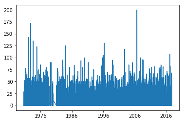

```python
pl.plot(Fechas, Data)
```

## 3. Pandas (Python Data Analysis Library)

O como simplificar la vida!

Esta es una librería de más alto nivel ya que se apoya en librerías como **numpy, matplotlib y datetime**. Pero permite organizar la información en fechas y columnas permitiendo realizar análisis de mayor complejidad. **Pandas** presenta algunos beneficios tales como:

- Manejo de la información por fechas: se pueden haer consultas directamente sobre las fechas.
- Incluye el uso de nombres sobre columnas.
- Tablas con multiples columnas a diferentes niveles.

Esto lo logra mediante el uso de 2 tipos de variables nuevas, las cuales son:

- Series: Piensen en un **np.array** pero en donde los indices son **datetime**.
- DataFrames: Es un **Series** pero con múltiples variables (una tabla de excel en python!!!).

Adicional a lo anterior cabe mencionar que:

- Lee y escribe en multiples formatos.
  - Eso incluye **excel!!**
- Todo lo hace a gran velocidad.

```python
import pandas as pd
```

```python
#Lectura de un archivo de excel tomando fechas y demas
Precip = pd.read_excel('P_26180240.xlsx', parse_dates=True, index_col=0)
```

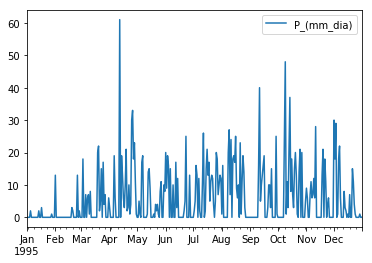

```python
#plot de un año cualquiera
Precip['1995'].plot()
```

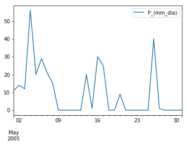

```python
#Plot de la precipitación en mayo
Precip['2005-5'].plot()
```

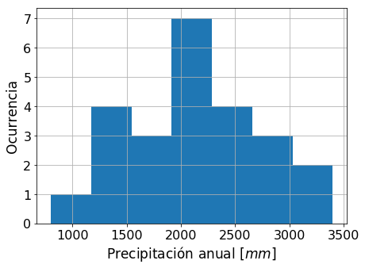

```python
#Arma el layout de la figura con una forma especifica
fig = pl.figure(figsize=(7,5))
#Le pasa el layout a un elemento que permite manejar los ejes.
ax = fig.add_subplot(111)
#Agrea anual la precipitacion y hace el histograma
Precip.resample('A').sum().hist(bins = 7, ax = ax)
#SEt de la figura editando el objeto axis (ax)
ax.tick_params(labelsize = 16)
ax.set_xlabel(u'Precipitación anual [$mm$]', size = 17)
ax.set_ylabel(u'Ocurrencia', size = 17)
ax.set_title(' ')
```

Como pueden ver en el ejemplo anterior, en **pandas** es posible cambiar de resolución temporal de una forma fácil, se deben conocer las letras asociadas a cada tipo:

- anual: A
- mensual: m
- diario: D
- horario: H
- minutos: M

Cada letra se puede combinar con un numero para asignar una escala temporal específica, por ejemplo para conocer como es la serie en su suma cada 5 días se escribe: 5D

```python
#Convierte a lluvia cada 5 dias sumandola (puede ser por otras metodologías, incluye propias)
Precip5D = Precip.resample('5D').sum()
```

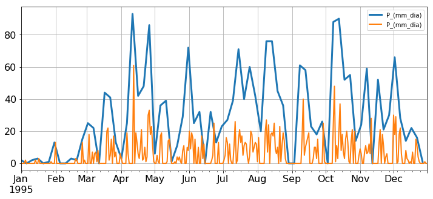

```python
fig = pl.figure(figsize=(12,5))
ax = fig.add_subplot(111)
Precip5D['1995'].plot(ax = ax, lw = 3)
Precip['1995'].plot(ax = ax, lw = 2)
ax.tick_params(labelsize = 16)
ax.grid()
```

También se pueden hacer consultas por año, mes, día, etc. Es decir, a pandas se le puede preguntar por los datos de un mes en específico o de todos así:

```
array([[<matplotlib.axes._subplots.AxesSubplot object at 0x7fc644309090>]], dtype=object)
```

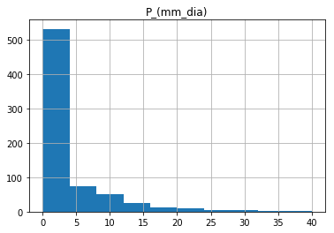

```python
Mes = Precip[Precip.index.month == 1]
Mes.hist()
```

### Ejercicio Pandas:

Teniendo en cuenta lo anterior, tome la serie de tiempo de precipitación y obtenga la media mensual multi-anual de la misma, grafíquela con sus bandas de confianza entendidas como: $\mu + \sigma$ y $\mu - \sigma$. Haga una gráfica de la que se sienta orgulloso!.

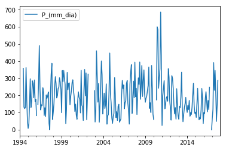

```python
# Escalado mensual y plot
Pm = Precip.resample('m').sum()
Pm.plot()
```

```python
Lm = []
Ls = []
for i in range(1,13):
    Lm.append(Pm[Pm.index.month == i].mean().values[0])
    Ls.append(Pm[Pm.index.month == i].std().values[0])
Lm = np.array(Lm)
Ls = np.array(Ls)
```

```python
Paleta = {'naranja':'#DBA901','azul':'#00FFFF',
    'gris':'#BDBDBD'}
```

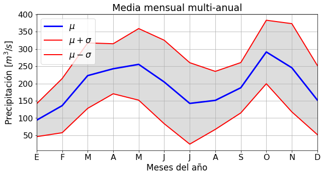

```python
#Lienzo
fig = pl.figure(figsize=(10,5))
#Tomar control del cuadro de graficos
ax =fig.add_subplot(111)
#Hacer figuras
pl.plot(Lm, 'b', lw = 3, label = '$\mu$')
pl.plot(Lm+Ls, 'r', lw = 2, label = '$\\mu + \\sigma$')
pl.plot(Lm-Ls, 'r', lw = 2, label = '$\\mu - \\sigma$')
pl.fill_between(range(12), Lm-Ls,Lm+Ls,
    color = Paleta['gris'],alpha = 0.5)
#Cambiar propiedades del plot
ax.set_xlim(0,11) #Cambiar limite en X
ax.tick_params(labelsize = 16) #Cambiar tamano de letras en ejes
ax.grid() #Poner grilla
ax.legend(loc = 0,fontsize = 'xx-large') #Legenda
#Cambiar ejes X para que diga los meses
axt = ax.set_xticks(np.arange(0,12))
Lab = ['E','F','M','A','M','J','J','A','S','O',
      'N','D']
axt = ax.set_xticklabels(Lab)
#Nombrar ejes y poner titulo
ax.set_xlabel('Meses', size = 17)
ax.set_xlabel(u'Meses del año', size = 17)
ax.set_ylabel(u'Precipitación [$m^3/s$]', size = 17)
ax.set_title('Media mensual multi-anual',size = 19)
#Guardar la figura
pl.savefig('Figura_ejemplo.png', bbox_inches = 'tight')
```

```python
#Invento datos
a = np.random.uniform(0,1,12)
b = np.random.normal(0,1,12)
#Pongo unas fechas
#Dates = pd.date_range('2001-01-01',periods=12, freq='M')
Dates = [str(i) for i in range(1,13)]
```

```python
#Une los vectores con dos filas y 100 columnas
c = np.vstack([Lm,Ls])
#Hace el DateFrame
DataF = pd.DataFrame(c.T, index=Lab,
    columns=['uniform', 'normal'])
```

```python
#Codigo para copiar un DataFrame a excel
Ex = pd.ExcelWriter('ArchivoPrueba.xlsx')
DataF.to_excel(Ex)
Ex.close()
```

### Ejercicio Lectura excel y procesado

En la carpeta **data** se encuentra un archivo llamado: **Q_diario.xlsx**, lea este archivo con *Pandas* y genere la figura de la curva de duración de caudales del mismo. No tenga en cuenta valores **atípicos** (localizados $4\sigma$ fuera).

Nota: La curva de duración de caudales tiene en el eje **X** las probabilidades de excedencia y en el eje **Y** los caudales asociados.

```python
DataFrame = pd.read_excel('Q_diario.xlsx',skiprows=0)
```

```python
#Valores y procesado
Data = DataFrame.values
Data = Data[np.isfinite(Data)]
pos = np.where(Data<Data.mean() + Data.std()*4.)[0]
Data = np.sort(Data[pos])[::-1]
#Eje X
Pos = np.arange(1, Data.size+1, dtype=float) / (Data.size+1)
```

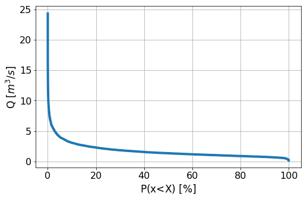

```python
fig = pl.figure(figsize=(8,5))
ax = fig.add_subplot(111)
pl.plot(Pos*100, Data, lw = 4)
ax.grid()
ax.tick_params(labelsize = 16)
ax.set_xlabel('P(x<X) $[\%]$', size = 17)
ax.set_ylabel('Q $[m^3/s]$', size = 17)
```

### Ejercicio: Ajuste estadístico

Realice un ajuste estadístico a los valores mínimos de la serie de tiempo de caudales.

```
array([[<matplotlib.axes._subplots.AxesSubplot object at 0x7fdb97840710>]], dtype=object)
```

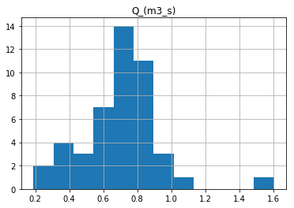

```python
DataFrame.resample('A').min().hist(bins = 12)
```

```python
#Obtiene los datos
Xo = DataFrame.resample('A').min().values.T[0]
Xo = Xo[Xo<1.4]
```

```python
#Obtiene los parametros de la funcion y la congela en ellos.
param = st.gumbel_l.fit(Xo)
func = st.gumbel_l.freeze(param[0], param[1])
#func = st.lognorm.freeze(param)
```

```python
ho,bo = np.histogram(Xo, bins=np.linspace(0,1.4,8))
ho = ho.astype(float)/ho.sum()
bm = (bo[:-1] + bo[1:])/2.
CDFo = np.cumsum(ho)
```

```python
CDFs = np.array([func.cdf(i) for i in bo])
hs = CDFs[1:] - CDFs[:-1]
```

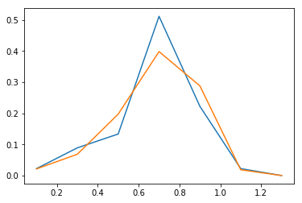

```python
pl.plot(bm, ho)
pl.plot(bm, hs)
```

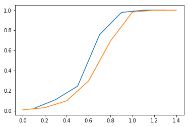

```python
pl.plot(bm, CDFo)
pl.plot(bo, CDFs)
```

### Continuación:

Continuando el ejercicio anterior, como se podría hacer un QQ-plot entre los percentiles de los datos observados y los simulados con una función?.

```python
QQs = np.array(map(func.ppf, np.linspace(0.1,1,20)))
QQo = [np.percentile(Xo, i*100) for i in np.linspace(0.1,1,20)]
```

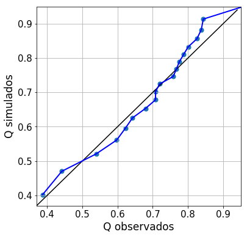

```python
fig = pl.figure(figsize=(6,6))
ax = fig.add_subplot(111)
pl.plot([0.37,0.94],[0.37,0.94],'k',lw=1.5)
pl.scatter(QQo, QQs, s = 50)
pl.plot(QQo, QQs, 'b', lw = 2)
ax.set_xlim(0.37, 0.95)
ax.set_ylim(0.37, 0.95)
ax.set_xlabel('Q observados', size = 17)
ax.set_ylabel('Q simulados', size = 17)
ax.grid()
ax.tick_params(labelsize = 15)
```

**Pregunta**: Como se obtendrían los caudales mínimos para los diferentes periodos de retorno?.